# Projekt M7986

- Zobrazit celý kód
- Skrýt celý kód
- Zobrazit zdrojový kód

Autor

Dráždilová, Červenka, Farkašovský

Publikováno

17. prosince 2025

# Směs dvourozměrných normálních rozdělení

Směs dvourozměrných normálních rozdělení je definovaná následovně

$$pN_2(\boldsymbol{\mu}_1, \boldsymbol{\Sigma}_1^2) + (1-p)N_2(\boldsymbol{\mu}_2, \boldsymbol{\Sigma}_2^2),$$

kde

$$\boldsymbol{\theta} =
(p, \mu_{11}, \mu_{12}, \sigma_{11}^2, \sigma_{12}^2, \rho_1,
\mu_{21}, \mu_{22}, \sigma_{21}^2, \sigma_{22}^2, \rho_2)^T.$$

$N_2(\boldsymbol{\mu}_i, \boldsymbol{\Sigma}_i)$, kde $i = 1, 2$, značí dvourozměrné normální rozdělení s parametry $\boldsymbol{\theta} = (\boldsymbol{\mu}, \boldsymbol{\Sigma})$, kde

$$\boldsymbol{\mu} = (\mu_1, \mu_2)^T,
\qquad
\boldsymbol{\Sigma} =
\begin{pmatrix}
\sigma_1^2 & \rho\,\sigma_1\sigma_2 \\
\rho\,\sigma_1\sigma_2 & \sigma_2^2
\end{pmatrix},$$

a kde $\boldsymbol{\theta} = (\mu_1, \mu_2, \sigma_1^2, \sigma_2^2, \rho)^T$, $(x, y)^T \in \mathbb{R}^2$, $\mu_j \in \mathbb{R}$, $\sigma_j^2 > 0$, $j = 1, 2$, $\rho \in (-1, 1)$.

Hustota je dána předpisem

$$f(x, y)
= \frac{1}{A}
\exp\!\left\{
-\frac{1}{B}
\left[
\frac{(x-\mu_1)^2}{\sigma_1^2}
- 2\rho\,\frac{(x-\mu_1)(y-\mu_2)}{\sigma_1\sigma_2}
+ \frac{(y-\mu_2)^2}{\sigma_2^2}
\right]
\right\},$$

kde

$$A = 2\pi\,\sigma_1\sigma_2\sqrt{1-\rho^2},
\qquad
B = 2(1-\rho^2).$$

## Kratký náhled na data

**Kód**

```r
data("faithful")
head(faithful)
```

```
  eruptions waiting
1     3.600      79
2     1.800      54
3     3.333      74
4     2.283      62
5     4.533      85
6     2.883      55
```

- **eruptions**: doba trvání erupce v minutách,
- **waiting**: čas čekaní na erupci v minutách.

## (a) Nakreslite histogram pre dobu čakania na erupciu a superponujte ho krivkou jadrového odhadu hustoty získaného z dát. Podobný histogram vykreslite aj pre dobu trvania erupcie;

**Kód**

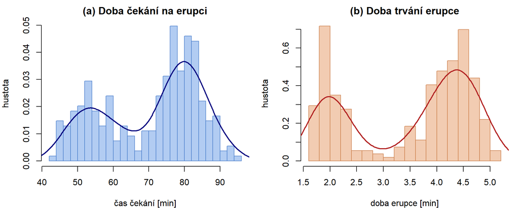

Obrázek 1: Histogramy doby čekaní na erupci a doby trvaní erupce s jadrovým odhadem hustoty.

```r
# Dva grafy vedle sebe
par(mfrow = c(1, 2), mar = c(4,4,2,1))

## 1) Histogram waiting
hist(
  faithful$waiting,
  breaks = 20,
  freq   = FALSE,
  main   = "(a) Doba čekání na erupci",
  xlab   = "čas čekání [min]",
  ylab   = "hustota",
  col    = rgb(0.4, 0.6, 0.9, 0.5),
  border = rgb(0.3, 0.5, 0.8, 0.9)
)
lines(
  density(faithful$waiting),
  lwd = 2,
  col = "navy"
)

## 2) Histogram eruptions
hist(
  faithful$eruptions,
  breaks = 20,
  freq   = FALSE,
  main   = "(b) Doba trvání erupce",
  xlab   = "doba erupce [min]",
  ylab   = "hustota",
  col    = rgb(0.9, 0.6, 0.4, 0.5),
  border = rgb(0.8, 0.5, 0.3, 0.9)
)
lines(
  density(faithful$eruptions),
  lwd = 2,
  col = "firebrick"
)

# Reset layout
par(mfrow = c(1, 1))
```

## (b) Naprogramujte funkciu hustoty zmiešaného dvojrozmerného normálneho rozdelenia `Mixdnorm2()`;

### Naprogramování funkce

**Kód**

```r
Mixdnorm2 <- function(x, y,
                      p,
                      mu1, Sigma1,
                      mu2, Sigma2)
{
  # kontrola
  if (p < 0 || p > 1) stop("p musí být v intervalu 0 až 1")

  # hustoty jednotlivých komponent
  f1 <- mvtnorm::dmvnorm(cbind(x, y), mean = mu1, sigma = Sigma1)
  f2 <- mvtnorm::dmvnorm(cbind(x, y), mean = mu2, sigma = Sigma2)

  # směs
  p * f1 + (1 - p) * f2
}
```

## (c) Pomocou funkcie `densityMclust()`, ktorej syntax samostatne naštudujte, odhadnite parametre zmiešaného dvojrozmerného normálneho rozdelenia. Získané odhady zaokrúhlite na štyri desatinné miesta a vložte do prehľadnej tabuľky. Všetky získané hodnoty riadne interpretujte.

**Kód**

```r
# parametr modelNames urcuje omezeni na kovariacni matici (tedy i na tvar komponent)
fitted_model <- densityMclust(faithful, modelNames = "VVV", G = 2, plot=FALSE)

means <- round(fitted_model$parameters$mean, 4)
prop <- round(fitted_model$parameters$pro, 4)
sigmas <- list()
for (i in 1:fitted_model$G) {
  sigmas[[i]] <- round(fitted_model$parameters$variance$sigma[,,i], 4)
}
# Odhadnute parametre z modelu
p      <- round(fitted_model$parameters$pro, 4)
mu1    <- round(fitted_model$parameters$mean[, 1], 4)
mu2    <- round(fitted_model$parameters$mean[, 2], 4)
Sigma1 <- round(fitted_model$parameters$variance$sigma[, , 1], 4)
Sigma2 <- round(fitted_model$parameters$variance$sigma[, , 2], 4)
```

Tabulka 1: Odhadnuté váhy komponent směsi dvou dvourozměrných normálních rozdělení

| Komponent | Odhad váhy |
| --- | --- |
| \(\hat{p}\) | 0.6441 |
| \(1-\hat{p}\) | 0.3559 |

Tabulka 1 zobrazuje odhad váhy první a druhé složky smíšeného modelu, tedy odhad pravděpodobnosti, že náhodné pozorování patří do první komponenty.

Tabulka 2: Odhadnuté střední hodnoty komponent

|  | \(\hat{\mu}_{i1}\) | \(\hat{\mu}_{i2}\) |
| --- | --- | --- |
| \(\boldsymbol{\hat{\mu}_1}\) | 4.2898 | 79.9695 |
| \(\boldsymbol{\hat{\mu}_2}\) | 2.0365 | 54.4799 |

Tabulka 2 zobrazuje odhady vektorů středních hodnot včetně jejich složek, tedy odhad průmerné délky erupce a odhad průměrného času čekání na erupci v jednotlivých složkách.

Tabulka 3: Kovarianční matice komponent (rozptyly a kovariancie)

|  | \(\hat{\sigma}_{11}^2\) | \(\hat{\sigma}_{12}\) | \(\hat{\sigma}_{22}^2\) |
| --- | --- | --- | --- |
| \(\boldsymbol{\hat{\Sigma}_1}\) | 0.1698 | 0.9387 | 36.0248 |
| \(\boldsymbol{\hat{\Sigma}_2}\) | 0.0693 | 0.4363 | 33.7052 |

Tabulka 3 zobrazuje odhady kovariančních matic (rozptyly a kovariance) jednotlivých složek smíšeného modelu.

### Vykreslení směsi s vyznačenými středními hodnotami a variancí jednotlivých komponent

**Kód**

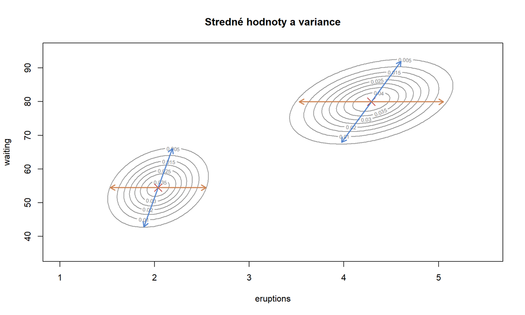

Obrázek 2: Vrstevnice hustoty směsi dvou dvourozměrných normálních rozdelení se středními hodnotami a směry variability jednotlivých komponent.

```r
plot(fitted_model, what = "density", data = NULL, xlim=c(1, 5.5), ylim = c(35, 95), main = "Stredné hodnoty a variance" )

means_unround <- fitted_model$parameters$mean
points(t(means_unround),
       pch = 4,
       col = "firebrick",
       cex = 2)

# smer variance prvni komponenty
eigen1 <- eigen(sigmas[[1]])
eig_val1 <- eigen1$values
eig_vec1 <- eigen1$vectors

# vyobrazime vektor delky dvou smerodatnych odchylek
scale <- 2

# smery variability * pocet smer. odchylek, ktere vykreslime
direction1 <- scale * sqrt(eig_val1[1]) * eig_vec1[,1]
direction2 <- scale * sqrt(eig_val1[2]) * eig_vec1[,2]

mu1 <- means_unround[,1]

# vykresleni sipek variability
col1 <- rgb(0.3, 0.5, 0.8, 0.9) # svetle modra
col2 <- rgb(0.8, 0.5, 0.3, 0.9) # svetle oranzova
arrows(mu1[1], mu1[2], mu1[1] + direction1[1], mu1[2] + direction1[2], col = col1, length = 0.1, lwd = 2)
arrows(mu1[1], mu1[2], mu1[1] - direction1[1], mu1[2] - direction1[2], col = col1, length = 0.1, lwd = 2)

arrows(mu1[1], mu1[2], mu1[1] + direction2[1], mu1[2] + direction2[2], col = col2, length = 0.1, lwd = 2)
arrows(mu1[1], mu1[2], mu1[1] - direction2[1], mu1[2] - direction2[2], col = col2, length = 0.1, lwd = 2)

# smer variance druhe komponenty
eigen2 <- eigen(sigmas[[2]])
eig_val2 <- eigen2$values
eig_vec2 <- eigen2$vectors

direction1 <- scale * sqrt(eig_val2[1]) * eig_vec2[,1]
direction2 <- scale * sqrt(eig_val2[2]) * eig_vec2[,2]

mu2 <- means_unround[,2]

# vykresleni sipek variability
arrows(mu2[1], mu2[2], mu2[1] + direction1[1], mu2[2] + direction1[2], col = col1, length = 0.1, lwd = 2)
arrows(mu2[1], mu2[2], mu2[1] - direction1[1], mu2[2] - direction1[2], col = col1, length = 0.1, lwd = 2)

arrows(mu2[1], mu2[2], mu2[1] + direction2[1], mu2[2] + direction2[2], col = col2, length = 0.1, lwd = 2)
arrows(mu2[1], mu2[2], mu2[1] - direction2[1], mu2[2] - direction2[2], col = col2, length = 0.1, lwd = 2)

title(main = "Stredné hodnoty a variance")
```

Obrázek 2 zobrazuje následující:

- **Střední hodnota (červený křížek)**
  - je střed elipsy a představuje typické/očekávané hodnoty dané komponenty (průměrná délka erupce a průměrná doba čekání).
- **Vrstevnice hustoty (elipsy)**
  - ukazují, jak jsou data rozložena kolem střední hodnoty.
- **Kovariance (tvar elipsy)**
  - naklonění elipsy značí nenulovou kovarianci.
- **Směr variability (barevné šipky)**
  - ukazují hlavní směry rozptylu (vlastní vektory kovarianční matice),
  - délka šipky je rovna dvoum směrodatným odchylkám v daném směru,
  - směrodatná odchylka v daném směru je dána odmocninou z vlastního čísla příslušné kovarianční matice.

## (d) Vykreslite bodový graf závislosti medzi dobou čakania na erupciu a dobou trvania erupcie a superponujte ho kontúrovým grafom:

- 1. hustoty zmiešaného dvojrozmerného normálneho rozdelenia, ktorej parametre odhadnite pomocou funkcie `densityMclust()` z balíčka mclust;
- 2. jadrového odhadu hustoty získaného pomocou funkcie `kde2d()`.

Počet bodov $(x, y)$, v ktorých budete hustotu počítať, zvoľte $2500 (nx = ny = 50)$.

**Kód**

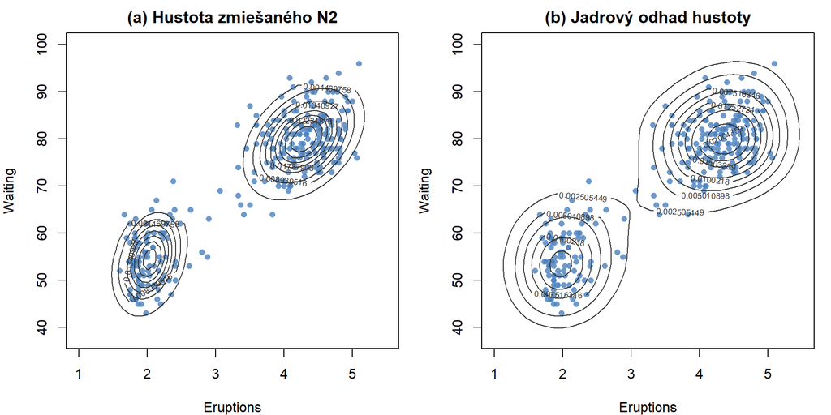

Obrázek 3: Porovnání hustoty smšsi dvou dvourozměrních normálních rozdelení a jadrového odhadu hustoty.

```r
col3 <- rgb(0.3, 0.5, 0.7, 0.8)
col4 <- rgb(0.4, 0.6, 0.9, 0.5)

n <- 50
xlim=c(1, 5.5)
ylim = c(38, 100)
x <- seq(xlim[1], xlim[2], length.out = n)
y <- seq(ylim[1], ylim[2], length.out = n)


M <- matrix(NA, nrow = n, ncol = n)
for (i in 1:n) {
  for (j in 1:n) {
    M[i, j] <- Mixdnorm2(x[i], y[j], p[1], mu1, Sigma1, mu2, Sigma2)
  }
}

Z <- MASS::kde2d(
  faithful$eruptions,
  faithful$waiting,
  lim = c(xlim[1], xlim[2], ylim[1], ylim[2]),
  n = n
)

k <- 10


# --- Dva grafy vedle sebe ---
par(mfrow = c(1, 2), mar = c(4, 4, 2, 1))

# 1) Mixture density
plot(
  faithful$eruptions, faithful$waiting,
  xlim = xlim,
  ylim = ylim,
  pch = 21, bg = col3,
  col = col4,
  cex = 0.9,
  xlab = "Eruptions", ylab = "Waiting",
  main = "(a) Hustota zmiešaného N2"
)
contour(x, y, M, drawlabels = TRUE, xlim = xlim, ylim = ylim,
        levels = seq(0, max(M), length = k + 1),
        add = TRUE, col = "grey20")

# 2) Kernel density
plot(
  faithful$eruptions, faithful$waiting,
  xlim = xlim,
  ylim = ylim,
  pch = 21, bg = col3,
  col = col4,
  cex = 0.9,
  xlab = "Eruptions", ylab = "Waiting",
  main = "(b) Jadrový odhad hustoty"
)
contour(Z, drawlabels = TRUE,
  xlim = xlim,
  ylim = ylim,
        levels = seq(0, max(Z$z), length = k + 1),
        add = TRUE, , col = "grey20")
```

### Ďalej pomocou funkcie `persp()` vykreslite 3D graf:

- 1. hustoty zmiešaného dvojrozmerného normálneho rozdelenia;
- 2. jadrového odhadu hustoty.

Hustotu rozdeľte na $k = 12$ ntervalov, kde hodnoty v týchto intervaloch budú zodpovedať farbám `sequential_hcl(12)`. Vytvorte animáciu zobrazujúcu náhľad na oba 3D- diagramy.

**Kód**

```r
GenGraphs <- function(theta) {
  k <- 12
  cols <- sequential_hcl(k)

  Mfacetval <- M[-1, -1] + M[-1, -n] + M[-n, -1] + M[-n, -n]
  Mfacetcol <- as.numeric(cut(Mfacetval, k))
  Zfacetval <- -Z$z[-1, -1] + Z$z[-1, -n] + Z$z[-n, -1] + Z$z[-n, -n]
  Zfacetcol <- as.numeric(cut(Zfacetval, k))

  par(mfrow = c(1,2), mar = c(3,3,3,3), pty = "s")

  persp(x, y, M,
        theta = theta,
        xlim = xlim,
        ylim = ylim,
        phi = 30,
        col = cols[Mfacetcol],
        xlab = "Eruptions", ylab = "Waiting", zlab = "Hustota",
        main = "(a) Hustota zmiešaného N2",
        d = 3,
        ticktype = "detailed",
        cex.axis = 0.8,
        cex.lab  = 1)


  persp(Z$x, Z$y, Z$z,
        theta = theta, phi = 30,
        xlim = xlim, ylim = ylim,
        col = cols[Zfacetcol],
        xlab = "Eruptions", ylab = "Waiting", zlab = "Hustota",
        main = "(b) Jádrový odhad hustoty",
        d = 3,
        ticktype = "detailed",
        cex.axis = 0.8,
        cex.lab  = 1)

}
```

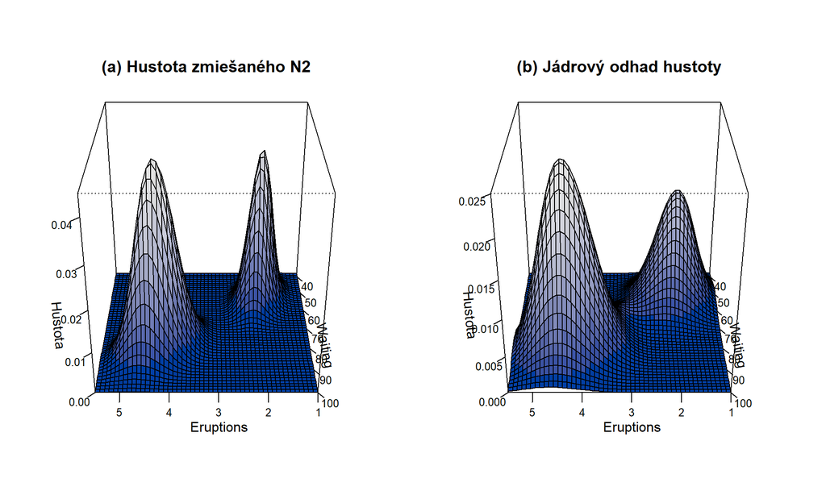

Obrázek 4: 3D zobrazení hustoty směsi dvou dvourozměrných normálních rozdělení a jádrového odhadu hustoty.